# Figure 5. Exiguobacterium R2567 and Pelomonas R780 regulate rice tillering through the strigolactone pathway

## 5E/F. Exiguobacterium R2567 and Pelomonas R780 alter the SL contents in root exudates and root tissues.

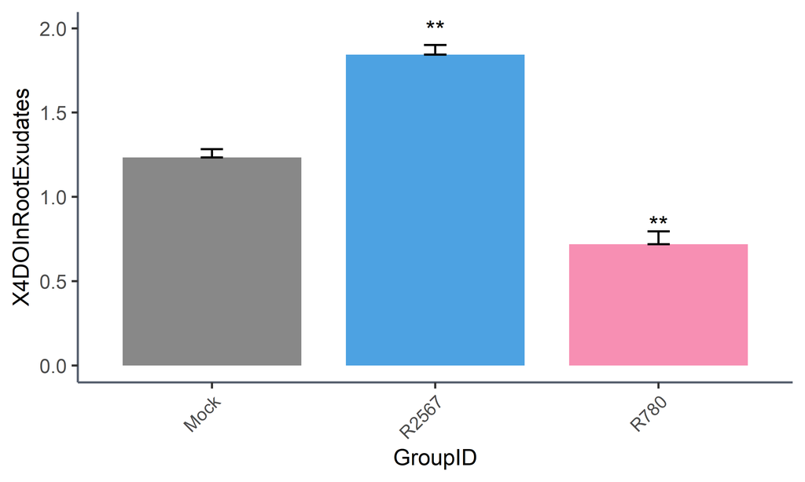

```r
#read input files
RawData = read.table("dataForFig5E.csv", header=T, sep=",")
#calculate plot data
phenotype = "X4DOInRootExudates"
ForPlot <- summarySE(RawData, measurevar = phenotype, groupvars ="GroupID")
ForPlot$GroupID = factor(ForPlot$GroupID, levels = c("Mock", "R2567", "R780"))
#statistics
SigTableFinnal = t(as.data.frame(c("group2", "method", "p", "padjFDR")))
colnames(SigTableFinnal) = c("group2", "method", "p", "padjFDR")
SigTableFinnal = SigTableFinnal[-1,]
#T.test
ForSig = RawData
ForSig = ForSig[, c("GroupID", phenotype)]
colnames(ForSig)[2] = "y"
TtestResult = compare_means(y ~ GroupID, data = ForSig, method = "t.test", paired = F,)
colnames(ForSig)[2] = phenotype

TtestResult = as.data.frame(TtestResult)
TtestResult$group3 = TtestResult$group1
TtestResult$group4 = TtestResult$group2
Delete = c()
for (n in 1:length(TtestResult[,1])){
  if ("Mock" %in% TtestResult$group1[n]){
  }else{if ("Mock" %in% TtestResult$group2[n]){
    TtestResult$group1[n] = TtestResult$group4[n]
    TtestResult$group2[n] = TtestResult$group3[n]
  }else{Delete = append(n, Delete)}
  }
}
TtestResult = TtestResult[(-1)*Delete,]
TtestResult$padjFDR = p.adjust(TtestResult$p, method = "fdr", n = length(TtestResult$p))
TtestResult = TtestResult[, c("group2", "method", "p", "padjFDR")]
SigTableFinnal =  TtestResult
#asterisk
for (padjmethod in c("p", "padjFDR")){
  asterisk = paste(padjmethod, "Asterisk", sep = "")
  for (m in 1:length(SigTableFinnal[,1])){
    ifelse (SigTableFinnal[[padjmethod]][m] < 0.001,
            SigTableFinnal[[asterisk]][m] <- "***",
            ifelse (SigTableFinnal[[padjmethod]][m] < 0.01,
                    SigTableFinnal[[asterisk]][m] <- "**",
                    ifelse (SigTableFinnal[[padjmethod]][m] < 0.05,
                            SigTableFinnal[[asterisk]][m] <- "*", SigTableFinnal[[asterisk]][m] <- "")))
  }
}
write.table(SigTableFinnal, file="StatisticsResultForFig5E.csv",append = F, quote = F, sep = ",", row.names = F, col.names = T)
padjmethod = "padjFDRAsterisk"
SigTableFinnal$GroupID = SigTableFinnal$group2
SigTableFinnal$asterisk = SigTableFinnal[[padjmethod]]
SigTableFinnal = SigTableFinnal[,c("GroupID", "asterisk")]
ForPlot = merge(ForPlot, SigTableFinnal, all = T)
ForPlot$padjmethod = padjmethod
write.table(ForPlot, file="SampleInformationForFig5E.csv",append = F, quote = F, sep = ",", row.names = F, col.names = T)
#prepare data for plot
ForPlot = merge(ForPlot, SigTableFinnal, all = T)
ForPlot$max = (ForPlot[[phenotype]] + ForPlot$se)*1.05
#save plot
p = ggplot(data = ForPlot, aes(x = GroupID, y = .data[[phenotype]], fill = GroupID)) +
  geom_bar(stat = "identity", width = 0.8) +
  geom_errorbar(aes(ymin = .data[[phenotype]], ymax = .data[[phenotype]]+se), width = .1) +
  geom_text(aes(x = GroupID, y = max, label = asterisk)) +
  scale_fill_manual(values = c("#888888", "#4DA2E2", "#F78FB3")) +
  theme(
    plot.background = element_rect(fill = "#FFFFFF"),
    panel.background = element_blank(),
    panel.grid.major.x = element_blank(),
    panel.grid.major.y = element_blank(), #主网格线
    panel.grid.minor.x = element_blank(), #次网格线
    panel.grid.minor.y = element_blank(),
    panel.border = element_blank(), #边框
    axis.title = element_text(size = 10),  #轴标题
    axis.text.x = element_text(size = 8, angle = 45, vjust = 1, hjust = 1), #文本
    axis.line = element_line(colour = "#57606f"),
    legend.title = element_blank(),
    legend.key = element_rect(fill = "#FFFFFF"),
    legend.position = "none"
  )

p = p + theme(axis.text.x = element_text(angle = 45, vjust = 1, hjust = 1))
p
```

```r
ggsave(p, filename = "Fig5E.pdf", width = 1.25, height = 2.5)
ggsave(p, filename = "Fig5E.png", width = 1.25, height = 2.5)
```

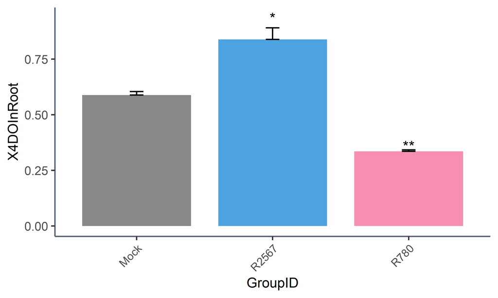

```r
#read input files
RawData = read.table("dataForFig5F.csv", header=T, sep=",")
#calculate plot data
phenotype = "X4DOInRoot"
ForPlot <- summarySE(RawData, measurevar = phenotype, groupvars ="GroupID")
ForPlot$GroupID = factor(ForPlot$GroupID, levels = c("Mock", "R2567", "R780"))
#statistics
SigTableFinnal = t(as.data.frame(c("group2", "method", "p", "padjFDR")))
colnames(SigTableFinnal) = c("group2", "method", "p", "padjFDR")
SigTableFinnal = SigTableFinnal[-1,]
#T.test
ForSig = RawData
ForSig = ForSig[, c("GroupID", phenotype)]
colnames(ForSig)[2] = "y"
TtestResult = compare_means(y ~ GroupID, data = ForSig, method = "t.test", paired = F,)
colnames(ForSig)[2] = phenotype

TtestResult = as.data.frame(TtestResult)
TtestResult$group3 = TtestResult$group1
TtestResult$group4 = TtestResult$group2
Delete = c()
for (n in 1:length(TtestResult[,1])){
  if ("Mock" %in% TtestResult$group1[n]){
  }else{if ("Mock" %in% TtestResult$group2[n]){
    TtestResult$group1[n] = TtestResult$group4[n]
    TtestResult$group2[n] = TtestResult$group3[n]
  }else{Delete = append(n, Delete)}
  }
}
TtestResult = TtestResult[(-1)*Delete,]
TtestResult$padjFDR = p.adjust(TtestResult$p, method = "fdr", n = length(TtestResult$p))
TtestResult = TtestResult[, c("group2", "method", "p", "padjFDR")]
SigTableFinnal =  TtestResult
#asterisk
for (padjmethod in c("p", "padjFDR")){
  asterisk = paste(padjmethod, "Asterisk", sep = "")
  for (m in 1:length(SigTableFinnal[,1])){
    ifelse (SigTableFinnal[[padjmethod]][m] < 0.001,
            SigTableFinnal[[asterisk]][m] <- "***",
            ifelse (SigTableFinnal[[padjmethod]][m] < 0.01,
                    SigTableFinnal[[asterisk]][m] <- "**",
                    ifelse (SigTableFinnal[[padjmethod]][m] < 0.05,
                            SigTableFinnal[[asterisk]][m] <- "*", SigTableFinnal[[asterisk]][m] <- "")))
  }
}
write.table(SigTableFinnal, file="StatisticsResultForFig5F.csv",append = F, quote = F, sep = ",", row.names = F, col.names = T)
padjmethod = "padjFDRAsterisk"
SigTableFinnal$GroupID = SigTableFinnal$group2
SigTableFinnal$asterisk = SigTableFinnal[[padjmethod]]
SigTableFinnal = SigTableFinnal[,c("GroupID", "asterisk")]
ForPlot = merge(ForPlot, SigTableFinnal, all = T)
ForPlot$padjmethod = padjmethod
write.table(ForPlot, file="SampleInformationForFig5F.csv",append = F, quote = F, sep = ",", row.names = F, col.names = T)
#prepare data for plot
ForPlot = merge(ForPlot, SigTableFinnal, all = T)
ForPlot$max = (ForPlot[[phenotype]] + ForPlot$se)*1.05
#save plot
p = ggplot(data = ForPlot, aes(x = GroupID, y = .data[[phenotype]], fill = GroupID)) +
  geom_bar(stat = "identity", width = 0.8) +
  geom_errorbar(aes(ymin = .data[[phenotype]], ymax = .data[[phenotype]]+se), width = .1) +
  geom_text(aes(x = GroupID, y = max, label = asterisk)) +
  scale_fill_manual(values = c("#888888", "#4DA2E2", "#F78FB3")) +
  theme(
    plot.background = element_rect(fill = "#FFFFFF"),
    panel.background = element_blank(),
    panel.grid.major.x = element_blank(),
    panel.grid.major.y = element_blank(), #主网格线
    panel.grid.minor.x = element_blank(), #次网格线
    panel.grid.minor.y = element_blank(),
    panel.border = element_blank(), #边框
    axis.title = element_text(size = 10),  #轴标题
    axis.text.x = element_text(size = 8, angle = 45, vjust = 1, hjust = 1), #文本
    axis.line = element_line(colour = "#57606f"),
    legend.title = element_blank(),
    legend.key = element_rect(fill = "#FFFFFF"),
    legend.position = "none"
  )

p = p + theme(axis.text.x = element_text(angle = 45, vjust = 1, hjust = 1))
p
```

```r
ggsave(p, filename = "Fig5F.pdf", width = 1.25, height = 2.5)
ggsave(p, filename = "Fig5F.png", width = 1.25, height = 2.5)
```

(E, F) Exiguobacterium R2567 and Pelomonas R780 alter the SL contents in root exudates and root tissues. Contents of 4DO in root exudates (E) and root tissues (F) of wild-type Nipponbare seedlings after inoculation with Exiguobacterium R2567 or Pelomonas R780 (n = 3, FDR adjusted P < 0.05, two-tailed Student’s t-test).

## 5G. Mutations in SL biosynthesis and signaling block the effects of Exiguobacterium R2567 or Pelomonas R780 on D53 protein level

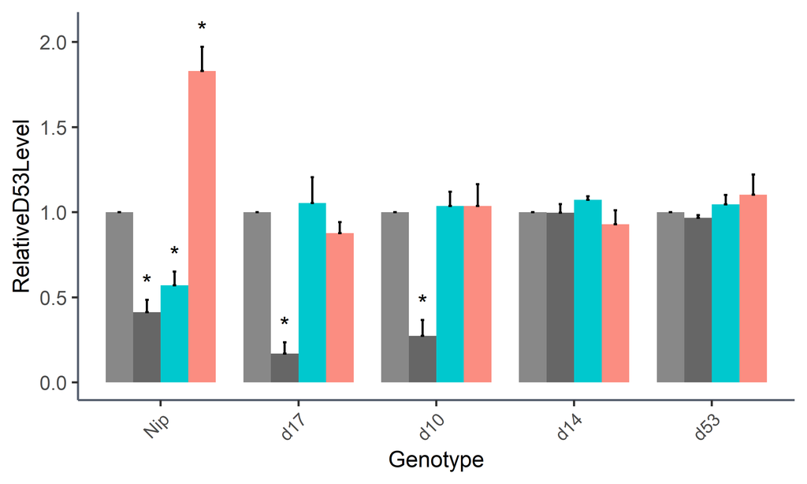

```r
#read input files
RawData = read.table("dataForFig5G.csv", header=T, sep=",")
#calculate plot data
phenotype = "RelativeD53Level"
genotype = c("Nip", "d17", "d10", "d14", "d53")
ForPlot = RawData
ForPlot = ForPlot[, c("GroupID", "Genotype","Bacteria", phenotype)]
ForPlot2 <- summarySE(ForPlot, measurevar = phenotype, groupvars = c("Bacteria", "Genotype"))
ForPlot2 <- unite(ForPlot2, "GroupID", Genotype, Bacteria, sep = "_", remove = FALSE)
ForPlot2$GroupID = factor(ForPlot2$GroupID, levels = c("Nip_rac-GR24", "Nip_GF", "Nip_R2567", "Nip_R780", "d17_rac-GR24", "d17_GF", "d17_R2567", "d17_R780", "d10_rac-GR24", "d10_GF", "d10_R2567", "d10_R780", "d14_rac-GR24", "d14_GF", "d14_R2567", "d14_R780", "d53_rac-GR24", "d53_GF", "d53_R2567", "d53_R780"))
ForPlot2$Bacteria = factor(ForPlot2$Bacteria, levels = c("Mock", "rac-GR24", "R2567", "R780"))
ForPlot2$Genotype = factor(ForPlot2$Genotype, levels = c("Nip", "d17", "d10", "d14", "d53"))
#statistics
SigTableFinnal = t(as.data.frame(c("group2", "method", "p")))
colnames(SigTableFinnal) = c("group2", "method", "p")
SigTableFinnal = SigTableFinnal[-1,]
# t-test
for (j in genotype){
  ForSig = ForPlot
  ForSig = ForSig[ForSig$Genotype %in% j,]
  colnames(ForSig)[4] = "y"
  TtestResult = compare_means(y ~ GroupID, data = ForSig, method = "t.test", paired = F,)
  colnames(ForSig)[4] = phenotype
  TtestResult = as.data.frame(TtestResult)
  TtestResult$group3 = TtestResult$group1
  TtestResult$group4 = TtestResult$group2
  Delete = c()
  for (n in 1:length(TtestResult[,1])){
    if (paste(j, "_Mock",sep = "") %in% TtestResult$group1[n]){
    }else{if (paste(j, "_Mock",sep = "") %in% TtestResult$group2[n]){
      TtestResult$group1[n] = TtestResult$group4[n]
      TtestResult$group2[n] = TtestResult$group3[n]
    }else{Delete = append(n, Delete)}
    }
  }
  TtestResult = TtestResult[(-1)*Delete,]
  TtestResult = TtestResult[, c("group2", "method", "p")]
  TtestResult$padjFDR = p.adjust(TtestResult$p, method = "fdr", n = length(TtestResult$p))
  TtestResult = TtestResult[, c("group2", "method", "p", "padjFDR")]
  SigTableFinnal = merge(SigTableFinnal, TtestResult, all = T)
}
for (padjmethod in c("p", "padjFDR")){
  asterisk = paste(padjmethod, "Asterisk", sep = "")
  for (m in 1:length(SigTableFinnal[,1])){
    ifelse (SigTableFinnal[[padjmethod]][m] < 0.001,
            SigTableFinnal[[asterisk]][m] <- "***",
            ifelse (SigTableFinnal[[padjmethod]][m] < 0.01,
                    SigTableFinnal[[asterisk]][m] <- "**",
                    ifelse (SigTableFinnal[[padjmethod]][m] < 0.05,
                            SigTableFinnal[[asterisk]][m] <- "*", SigTableFinnal[[asterisk]][m] <- "")))
  }
}
write.table(SigTableFinnal, file = paste("StatisticsResultForFig5G.csv"), append = F, quote = F, sep = ",", row.names = F, col.names = T)
write.table(ForPlot2, file = paste("SampleInformationForFig5G.csv"), append = F, quote = F, sep = ",", row.names = F, col.names = T)
ForPlot2$max=(ForPlot2[[phenotype]]+ForPlot2$se)+0.1
colnames(SigTableFinnal)[1] = "GroupID"
ForPlot2 = merge(ForPlot2, SigTableFinnal, all = T)
#save plot
p = ggplot(data = ForPlot2, mapping = aes(x = Genotype, y = .data[[phenotype]], fill = Bacteria)) +
  geom_bar(stat = "identity", width = 0.8, position = position_dodge(), size = 0.3) +
  geom_errorbar(aes(ymin = .data[[phenotype]], ymax = .data[[phenotype]] + se), width = .1, position = position_dodge(0.8)) +
  geom_text(aes(y = max, label = padjFDRAsterisk), position = position_dodge(0.8)) +
  scale_fill_manual(values = c("#888888", "#666666", "#00c8ce", "#fb8d81")) +
  #"#fb8d81"
  theme(
    plot.background=element_rect(fill = "#FFFFFF"),
    panel.background = element_blank(),
    panel.grid.major.x = element_blank(),
    panel.grid.major.y = element_blank(),
    panel.grid.minor.x = element_blank(),
    panel.grid.minor.y = element_blank(),
    panel.border = element_blank(),
    axis.title = element_text(size = 10),
    axis.text.x = element_text(size = 8, angle = 45, vjust = 1, hjust = 1),
    axis.line = element_line(colour = "#57606f"),
    legend.title = element_blank(),
    legend.key = element_rect(fill = "#FFFFFF"),
    legend.position = "none"
  )
p=p+theme(axis.text.x=element_text(angle=45,vjust=1, hjust=1))
p
```

```r
ggsave(p, filename = paste("Fig5G.pdf"), width = 7, height = 2.2)
ggsave(p, filename = paste("Fig5G.png"), width = 7, height = 2.2)
```